# Регрессия на симуляции

*Полезные ссылки*  
https://www.machinelearningplus.com/machine-learning/complete-introduction-linear-regression-r/  
https://excelkingdom.blogspot.com/2018/11/what-is-difference-between-rnormrunif.html  
https://aosmith.rbind.io/2018/01/09/simulate-simulate-part1  
https://cran.r-project.org/web/packages/jtools/vignettes/summ.html

#Подготовка пакетов и данных Устанавливаем пакеты `car` и `jtools` , а также `sjPlot` и `skimr`, если у вас их нет, остальные просто подключаем

```r
library(ggplot2)
library(tidyverse)
library(sjPlot)
library(skimr)
library(car)
library(jtools)
```

Чтобы лучше понять, как можно найти существующие в данных тренды, иногда полезно эти самые тренды задать. Для этого используются различные **симуляции**. Сегодня мы с вами создадим несколько наборов данных по заданным нами правилам, а потом попытаемся восстановить эти правила с помощью метода линейно регрессии.

*Вопрос: Из каких элементов состоит уравнение парной регрессии?*  
*Ответ:* $Y = \beta_{0} + \beta_{1} * X_{i} + e_{i}$

Давайте сначала создадим все переменные из правой части формулы. Представим, что X - это уровень мотивации, который в нашей выборке из 500 человек распределен абсолютно случайно (как и должно быть в идеальном мире).

Для создания случайного распределения используются различные правила. Чтобы упростить жизнь R (и чтобы у нас всех получились одинаковые результаты), зададим “точку отсчета” - число 16 (можно любое другое)

```r
set.seed(16)
```

Для создания случайного (значит, подчиняющегося закону нормального) распределения используем функцию `rnorm` со следующими аргументами: количество наблюдений (500), среднее (0), стандартное отклонение (1). Проверим, что получилось, с помощью функции `skim` из пакета `skimr`.

```r
motiv <- rnorm(n = 500, mean = 0, sd = 1)
skim(motiv)
```

Data summary

| Name | motiv |
| --- | --- |
| Number of rows | 500 |
| Number of columns | 1 |
| _______________________ |  |
| Column type frequency: |  |
| numeric | 1 |
| ________________________ |  |
| Group variables | None |

**Variable type: numeric**

| skim_variable | n_missing | complete_rate | mean | sd | p0 | p25 | p50 | p75 | p100 | hist |
| --- | --- | --- | --- | --- | --- | --- | --- | --- | --- | --- |
| data | 0 | 1 | 0.05 | 0.97 | -2.75 | -0.57 | 0.02 | 0.73 | 3.25 | ▁▆▇▃▁ |

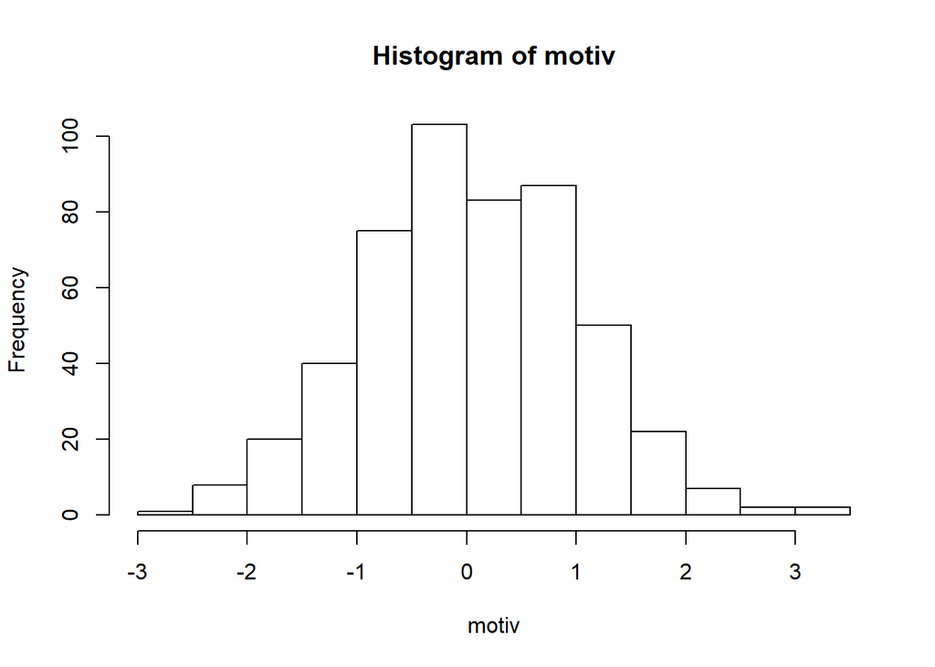

```r
hist(motiv)
```

*Опишите переменную motiv* Переменная измерена на интервальной шкале, среднее = 0.05, стандартное отклонение = 0.97, минимум = -2.75, максимум = 3.25, рапсределение имеет форму нормального

*Какой еще элемент формулы есть у каждого наблюдения?*

Зададим нормальное распределение для ошибки со средним = 0 и стандартным отклонением = 0.1 Проверим, что получилось.

```r
e <- rnorm(n = 500, mean = 0, sd = 0.1)
skim(e)
```

Data summary

| Name | e |
| --- | --- |
| Number of rows | 500 |
| Number of columns | 1 |
| _______________________ |  |
| Column type frequency: |  |
| numeric | 1 |
| ________________________ |  |
| Group variables | None |

**Variable type: numeric**

| skim_variable | n_missing | complete_rate | mean | sd | p0 | p25 | p50 | p75 | p100 | hist |
| --- | --- | --- | --- | --- | --- | --- | --- | --- | --- | --- |
| data | 0 | 1 | 0 | 0.1 | -0.33 | -0.06 | 0.01 | 0.07 | 0.35 | ▁▃▇▃▁ |

Соберем существуюшие переменные в датафрейм

```r
df <- data.frame(motiv, e)
```

Наконец, представим, что в нашем идеальном мире стандартизированный балл за некоторый тест Y при средней мотивации равен 0.25, а при возрастании мотивации на единицу увеличивается на 0.7. Создадим такую переменную и посмотрим на ее распределение.

```r
df$score <- 0.25 + 0.7 *  df$motiv + df$e
skim(df$score)
```

Data summary

| Name | df$score |
| --- | --- |
| Number of rows | 500 |
| Number of columns | 1 |
| _______________________ |  |
| Column type frequency: |  |
| numeric | 1 |
| ________________________ |  |
| Group variables | None |

**Variable type: numeric**

| skim_variable | n_missing | complete_rate | mean | sd | p0 | p25 | p50 | p75 | p100 | hist |
| --- | --- | --- | --- | --- | --- | --- | --- | --- | --- | --- |
| data | 0 | 1 | 0.29 | 0.69 | -1.73 | -0.15 | 0.24 | 0.77 | 2.58 | ▁▅▇▃▁ |

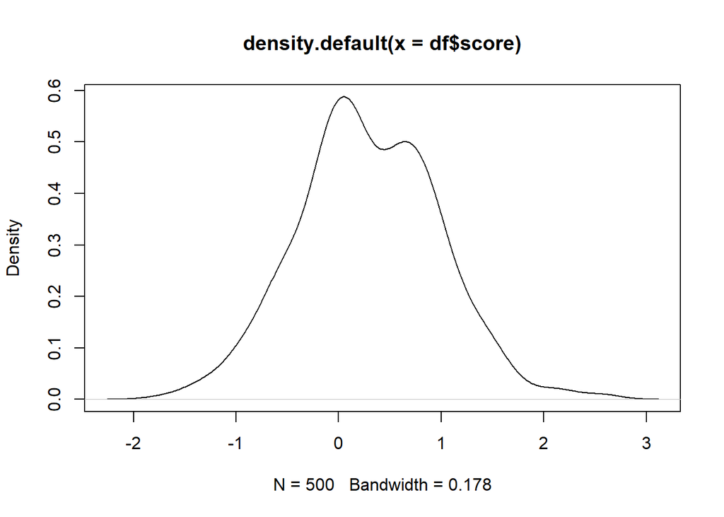

```r
plot(density(df$score))
```

Построим график для линейной связи между мотивацией ученика и его тестовым баллом. Опишите график.

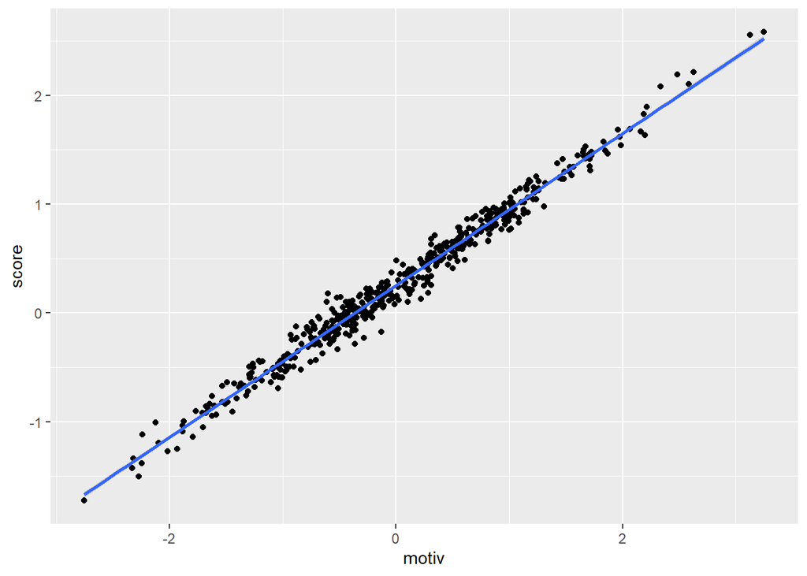

```r
ggplot(df,aes(x = motiv, y = score)) +
  geom_point() +
  geom_smooth(method = "lm")
```

# Простая парная регрессия

Для того, чтобы сделать регрессионный анализ в R, нужно воспользоваться стандартной функцией `lm` (linear model).

```r
?lm
```

```
## starting httpd help server ... done
```

В функции lm мы задаем данные и формулу: `зависимая переменная ~ независимая переменная`. Если нужно добавить еще одну независимую переменну, это делается через `+` : `зависимая переменная ~ независимая переменная1 + независимая переменная2`.

Итак, проверим модель с баллом в качестве зависимой переменной и одной независимой - уровнем мотивации.

```r
model1 <- lm(data = df, score ~ motiv)
summary(model1)
```

```
##
## Call:
## lm(formula = score ~ motiv, data = df)
##
## Residuals:
##      Min       1Q   Median       3Q      Max
## -0.33650 -0.06142  0.00173  0.06096  0.34293
##
## Coefficients:
##             Estimate Std. Error t value Pr(>|t|)
## (Intercept) 0.253474   0.004413   57.44   <2e-16 ***
## motiv       0.698349   0.004543  153.73   <2e-16 ***
## ---
## Signif. codes:  0 '***' 0.001 '**' 0.01 '*' 0.05 '.' 0.1 ' ' 1
##
## Residual standard error: 0.09855 on 498 degrees of freedom
## Multiple R-squared:  0.9794, Adjusted R-squared:  0.9793
## F-statistic: 2.363e+04 on 1 and 498 DF,  p-value: < 2.2e-16
```

Предскажем зависимую переменную, используя функцию `predict`, а затем построим график для линейной связи предсказанных и наблюдаемых баллов и проверим их корреляцию.

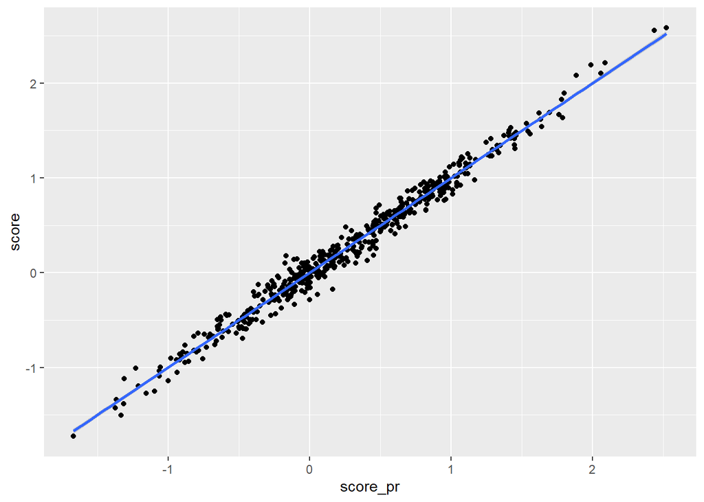

```r
df$score_pr <- predict(model1)

ggplot(df,aes(x = score_pr, y = score)) +
  geom_point() +
  geom_smooth(method = "lm")
```

```r
cor.test(df$score_pr, df$score)
```

```
##
##  Pearson's product-moment correlation
##
## data:  df$score_pr and df$score
## t = 153.73, df = 498, p-value < 2.2e-16
## alternative hypothesis: true correlation is not equal to 0
## 95 percent confidence interval:
##  0.9876453 0.9912923
## sample estimates:
##       cor
## 0.9896271
```

[Прочитайте, как определить линейность связи, нормальность остатков и гомоскедастичность модели](http://www.sthda.com/english/articles/39-regression-model-diagnostics/161-linear-regression-assumptions-and-diagnostics-in-r-essentials/)  
Обратим внимание на график 2 - QQ plot для остатков. *Проинтерпретируйте его.*

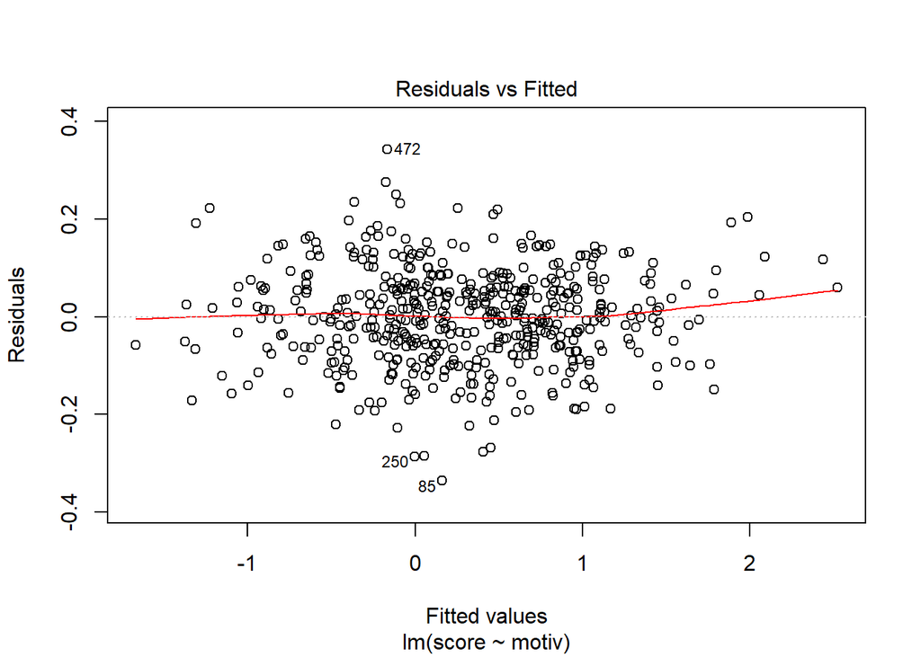

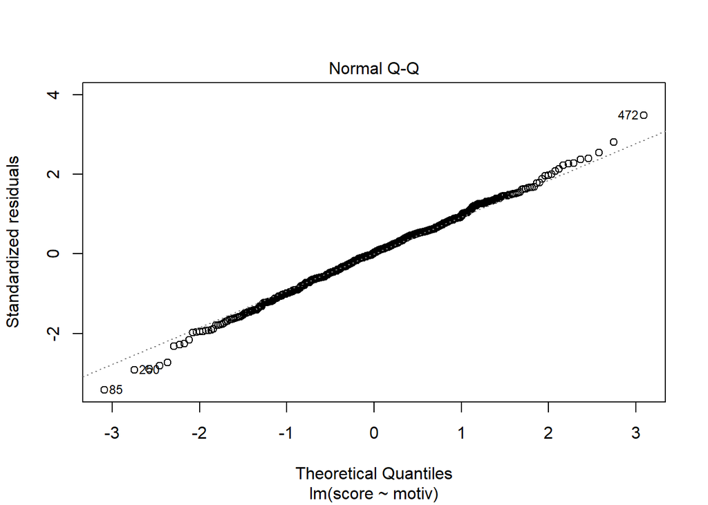

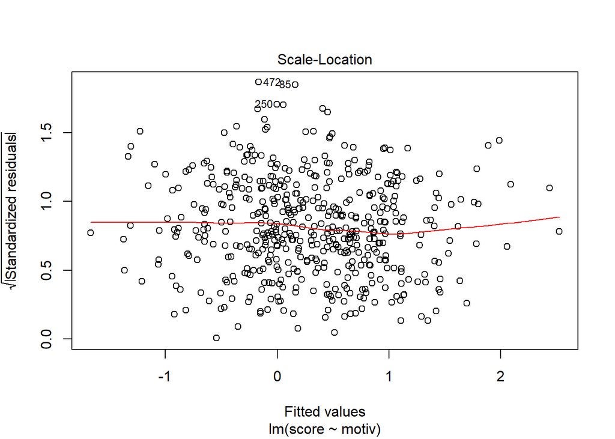

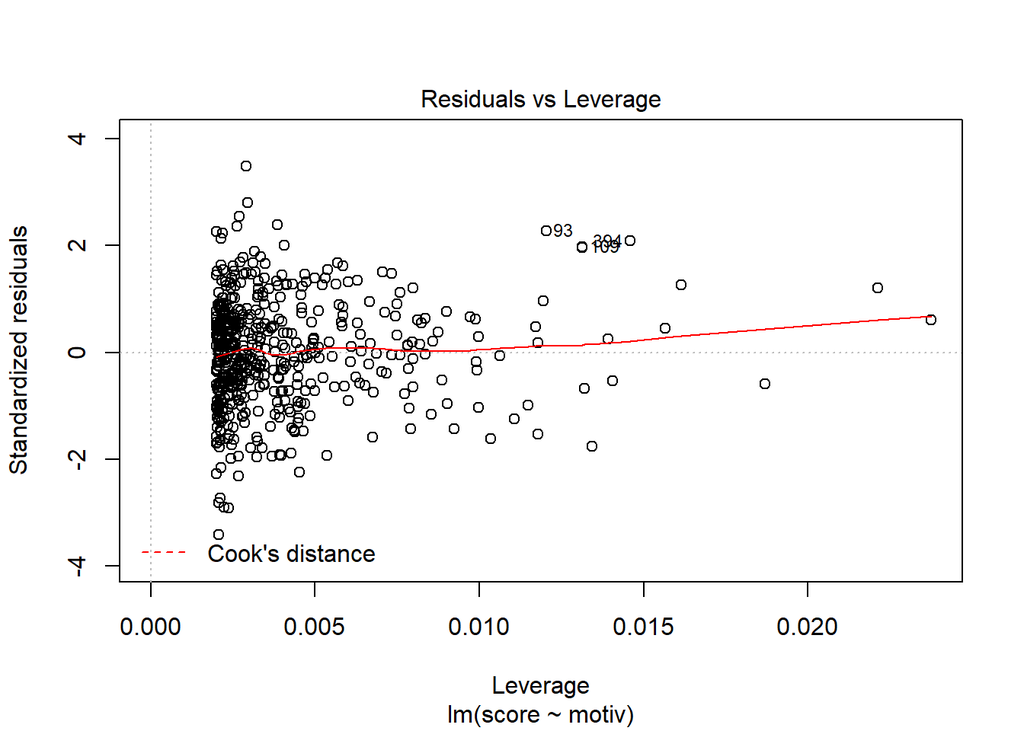

```r
plot(model1)
```

Второй график - это QQ plot для ошибок. Он показывает, нормально ли распределены ошибки. По оси X - теретическое распределение ошибок, то, которое мы ожидаем увидеть. По оси Y - то, что есть у нас в данных. Если все точки лежат на нарисованной линии - все идеально. Наши немного отклоняются по краям, то есть в минимальных и максимальных значениях распределение немного не такое, как мы ожидали, хотя в целом нормальное. Цифрами обозначены номера наблюдений с аномальными значениями - можем прямо в данных посмотреть, что с ними творится.

*Измените одну переменную так, чтобы коэффициент $\beta1$ стал менее точным. Сделайте новый датасет или уравнение, постройте график для линейной связи, рассчитайте новую модель и сравните коэффициенты*

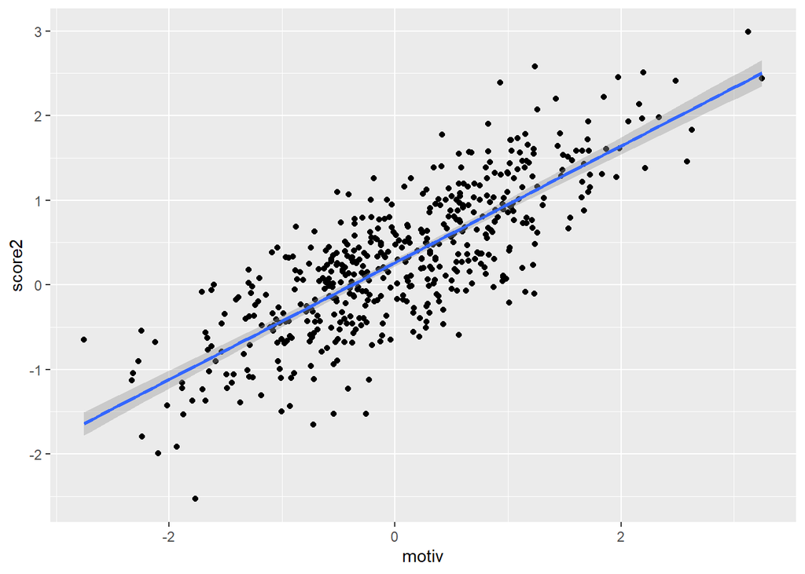

```r
df$e2 <- rnorm(n = 500, mean = 0, sd = 0.5)
df$score2 <- 0.25 + 0.7 *  df$motiv + df$e2

ggplot(df,aes(x = motiv, y = score2)) +
  geom_point() +
  geom_smooth(method = "lm")
```

```r
model1a <- lm(data = df, score2 ~ motiv)
summary(model1a)
```

```
##
## Call:
## lm(formula = score2 ~ motiv, data = df)
##
## Residuals:
##     Min      1Q  Median      3Q     Max
## -1.6091 -0.3461  0.0124  0.3723  1.4872
##
## Coefficients:
##             Estimate Std. Error t value Pr(>|t|)
## (Intercept)  0.26114    0.02290   11.40   <2e-16 ***
## motiv        0.69012    0.02357   29.28   <2e-16 ***
## ---
## Signif. codes:  0 '***' 0.001 '**' 0.01 '*' 0.05 '.' 0.1 ' ' 1
##
## Residual standard error: 0.5113 on 498 degrees of freedom
## Multiple R-squared:  0.6325, Adjusted R-squared:  0.6318
## F-statistic: 857.2 on 1 and 498 DF,  p-value: < 2.2e-16
```

## Добавляем независимую переменную на порядковой шкале

Сгенерируем переменную “Количество книг дома” с тремя категориями (“0-25”, “26-100”,“более 100”), которые не связаны с уровнем мотивации. Категория “26-100” будет самой многочисленной (у 180 человек), остальные - у 160 каждая.

```r
df$book = rep( c("0-25", "26-100","более 100"), c(160,180,160))
table(df$book)
```

```
##
##      0-25    26-100 более 100
##       160       180       160
```

Скорректируем нашу зависимую переменную так, чтобы при измнении уровня мотивации на 1 балл за тест увеличивался на 0.7, ученики, имеющие 26-100 книг дома, получили балл выше на 0.25 чем те, которые имеют 0-25, а те, которые имеют более 100 книг дома - на 0.55. При всех X=0 Y принимает значение 0.25.

```r
df$score <- 0.25 + 0.7 *  df$motiv + 0.25*(df$book == "26-100") + 0.55*(df$book == "более 100") + df$e
```

Проверим модель, где зависимая переменная - балл, а независимые - уровень мотивации и количество книг дома. *Проинтерпретируйте результаты*

```r
model2 <- lm(data = df, score ~ motiv + book)
summary(model2)
```

```
##
## Call:
## lm(formula = score ~ motiv + book, data = df)
##
## Residuals:
##      Min       1Q   Median       3Q      Max
## -0.34527 -0.06023  0.00303  0.06429  0.35384
##
## Coefficients:
##               Estimate Std. Error t value Pr(>|t|)
## (Intercept)   0.262295   0.007781   33.71   <2e-16 ***
## motiv         0.698708   0.004542  153.84   <2e-16 ***
## book26-100    0.242798   0.010695   22.70   <2e-16 ***
## bookболее 100 0.530482   0.011015   48.16   <2e-16 ***
## ---
## Signif. codes:  0 '***' 0.001 '**' 0.01 '*' 0.05 '.' 0.1 ' ' 1
##
## Residual standard error: 0.09843 on 496 degrees of freedom
## Multiple R-squared:  0.9818, Adjusted R-squared:  0.9816
## F-statistic:  8896 on 3 and 496 DF,  p-value: < 2.2e-16
```

Сделайте референтной переменной категорию “более 100”.

```r
model2 <- lm(data = df, score ~ motiv + fct_relevel(book,"более 100", "0-25", "26-100"))
summary(model2)
```

```
##
## Call:
## lm(formula = score ~ motiv + fct_relevel(book, "более 100", "0-25",
##     "26-100"), data = df)
##
## Residuals:
##      Min       1Q   Median       3Q      Max
## -0.34527 -0.06023  0.00303  0.06429  0.35384
##
## Coefficients:
##                                                         Estimate Std. Error
## (Intercept)                                             0.792777   0.007797
## motiv                                                   0.698708   0.004542
## fct_relevel(book, "более 100", "0-25", "26-100")0-25   -0.530482   0.011015
## fct_relevel(book, "более 100", "0-25", "26-100")26-100 -0.287684   0.010700
##                                                        t value Pr(>|t|)
## (Intercept)                                             101.67   <2e-16 ***
## motiv                                                   153.84   <2e-16 ***
## fct_relevel(book, "более 100", "0-25", "26-100")0-25    -48.16   <2e-16 ***
## fct_relevel(book, "более 100", "0-25", "26-100")26-100  -26.89   <2e-16 ***
## ---
## Signif. codes:  0 '***' 0.001 '**' 0.01 '*' 0.05 '.' 0.1 ' ' 1
##
## Residual standard error: 0.09843 on 496 degrees of freedom
## Multiple R-squared:  0.9818, Adjusted R-squared:  0.9816
## F-statistic:  8896 on 3 and 496 DF,  p-value: < 2.2e-16
```

Сделаем красивую табличку, используя функцию `tab_model` из пакета `sjPlot`. Обязательный аргумент - сама модель. Мы еще зададим отображение стандартных ошибок и t-статистики.

```r
?tab_model
tab_model(model2,show.se = TRUE,
          show.stat = T)
```

|  | score |  |  |  |  |
| --- | --- | --- | --- | --- | --- |
| Predictors | Estimates | std. Error | CI | Statistic | p |
| (Intercept) | 0.79 | 0.01 | 0.78 – 0.81 | 101.67 | **<0.001** |
| motiv | 0.70 | 0.00 | 0.69 – 0.71 | 153.84 | **<0.001** |
| fct_relevel(book, “более 100”, “0-25”, “26-100”) [fct_relevel(book, “более 100”, “0-25”, “26-100”)0-25] | -0.53 | 0.01 | -0.55 – -0.51 | -48.16 | **<0.001** |
| fct_relevel(book, “более 100”, “0-25”, “26-100”) [fct_relevel(book, “более 100”, “0-25”, “26-100”)26-100] | -0.29 | 0.01 | -0.31 – -0.27 | -26.89 | **<0.001** |
| Observations | 500 |  |  |  |  |
| R<sup>2</sup> / R<sup>2</sup> adjusted | 0.982 / 0.982 |  |  |  |  |

Проверьте мультиколлинеарность (команда vif, применяется для всей модели).

```r
vif(model2)
```

```
##                                                      GVIF Df GVIF^(1/(2*Df))
## motiv                                            1.001956  1        1.000978
## fct_relevel(book, "более 100", "0-25", "26-100") 1.001956  2        1.000489
```

Для визуализации результатов регрессии часто используется пакет `jtools`, однако много функций оттуда перестали поддерживать и они не работают в новых версиях R.

```r
# effect_plot(model1, pred = motiv,  interval = TRUE) # работает не у всех
```

Поэтому обратимся к нашему старому другу - пакету `sjPlot`.

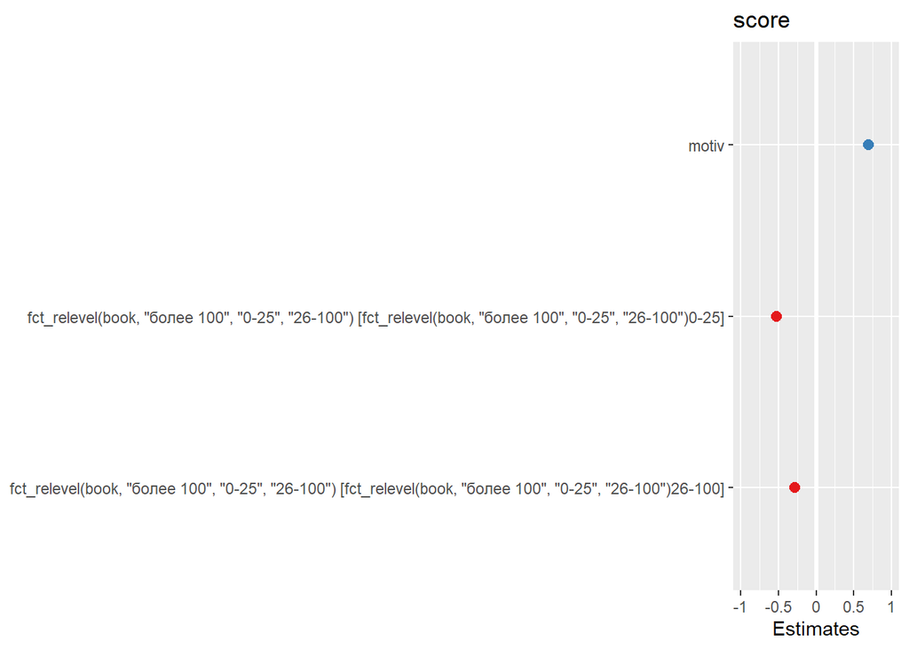

```r
?plot_model
plot_model(model2)
```

## Мультиколлинеарность

Создадим переменную `интерес`, сильно связанную с переменной `мотивация`

```r
df$inter <- df$motiv + df$e*10
cor(df$motiv, df$inter)
```

```
## [1] 0.6963096
```

Построим модель с обеими независимыми переменными (мотивация и интерес), не забывая про книжки дома. Сравним коэффициенты в моделях 2 и 3, используя функцию `tab_model`. Посмотрим на vif. Что означают эти значения? Что нужно сделать? (ответ - убрать обну из переменных с высоким vif)

```r
model3 <- lm(data = df, score ~ motiv + inter + fct_relevel(book,"более 100", "0-25", "26-100"))

tab_model(model2, model3)
```

|  | score |  |  | score |  |  |
| --- | --- | --- | --- | --- | --- | --- |
| Predictors | Estimates | CI | p | Estimates | CI | p |
| (Intercept) | 0.79 | 0.78 – 0.81 | **<0.001** | 0.80 | 0.80 – 0.80 | **<0.001** |
| motiv | 0.70 | 0.69 – 0.71 | **<0.001** | 0.60 | 0.60 – 0.60 | **<0.001** |
| fct_relevel(book, “более 100”, “0-25”, “26-100”) [fct_relevel(book, “более 100”, “0-25”, “26-100”)0-25] | -0.53 | -0.55 – -0.51 | **<0.001** | -0.55 | -0.55 – -0.55 | **<0.001** |
| fct_relevel(book, “более 100”, “0-25”, “26-100”) [fct_relevel(book, “более 100”, “0-25”, “26-100”)26-100] | -0.29 | -0.31 – -0.27 | **<0.001** | -0.30 | -0.30 – -0.30 | **<0.001** |
| inter |  |  |  | 0.10 | 0.10 – 0.10 | **<0.001** |
| Observations | 500 |  |  | 500 |  |  |
| R<sup>2</sup> / R<sup>2</sup> adjusted | 0.982 / 0.982 |  |  | 1.000 / 1.000 |  |  |

```r
vif(model3)
```

```
##                                                      GVIF Df GVIF^(1/(2*Df))
## motiv                                            1.956143  1        1.398622
## inter                                            1.953762  1        1.397770
## fct_relevel(book, "более 100", "0-25", "26-100") 1.008455  2        1.002107
```

# Самостоятельная работа

Сгенерируйте новый датасет с 600 наблюдениями и следующими переменными: score - балл по чтению sex = пол ученика (0-мальчик, 1 - девочка) int = интерес к чтению (стандартизированный, чем больше, тем выше интерес) bull = шкала буллинга (стандартизированная, чем больше, тем чаще буллят)

Мы знаем, что балл по чтению увеличивается на 0.3 для девочек, на 0.5 при увеличении КВАДРАТА интереса к чтению на 1 стандартное отклонение и уменьшается на 0.2 при увеличении уровня буллинга на 1 стандартное отклонение. Не забудьте про ошибки (сделайте их не очень большими)

```r
sex = rep( c("Boy", "Girl"), c(310,290))
int <- rnorm(n = 600, mean = 0, sd = 1)
bull <- rnorm(n = 600, mean = 0, sd = 1)
e <- rnorm(n = 600, mean = 0, sd = 0.3)
df2 <- data.frame(sex, int, bull, e)
df2$read <- 0 + 0.3*(df2$sex == "Girl") + 0.5*(df2$int^2) - 0.2*df2$bull + df2$e
```

Сделайте табличку с двумя моделями, чтобы ответить на вопрос о связи между уровнем буллинга и баллами по чтению: в первой модели независимой переменной выступает только буллинг, во второй - буллинг при контроле остальных переменных. Опишите результаты - коэффициенты, качество модели. Сравните модели. Интерпретируйте коэффициенты.

```r
m1 <-  lm(data = df2, read ~ bull)
summary(m1)
```

```
##
## Call:
## lm(formula = read ~ bull, data = df2)
##
## Residuals:
##     Min      1Q  Median      3Q     Max
## -1.4038 -0.5230 -0.1788  0.2601  9.4981
##
## Coefficients:
##             Estimate Std. Error t value Pr(>|t|)
## (Intercept)  0.65615    0.03648   17.99  < 2e-16 ***
## bull        -0.20960    0.03639   -5.76 1.35e-08 ***
## ---
## Signif. codes:  0 '***' 0.001 '**' 0.01 '*' 0.05 '.' 0.1 ' ' 1
##
## Residual standard error: 0.8934 on 598 degrees of freedom
## Multiple R-squared:  0.05257,    Adjusted R-squared:  0.05098
## F-statistic: 33.18 on 1 and 598 DF,  p-value: 1.345e-08
```

```r
m2 <-  lm(data = df2, read ~ bull + int + sex)
summary(m2)
```

```
##
## Call:
## lm(formula = read ~ bull + int + sex, data = df2)
##
## Residuals:
##     Min      1Q  Median      3Q     Max
## -1.2350 -0.4987 -0.1990  0.2573  9.0903
##
## Coefficients:
##             Estimate Std. Error t value Pr(>|t|)
## (Intercept)  0.48156    0.04978   9.674  < 2e-16 ***
## bull        -0.19706    0.03573  -5.516 5.17e-08 ***
## int         -0.05685    0.03506  -1.622    0.105
## sexGirl      0.35693    0.07166   4.981 8.31e-07 ***
## ---
## Signif. codes:  0 '***' 0.001 '**' 0.01 '*' 0.05 '.' 0.1 ' ' 1
##
## Residual standard error: 0.8749 on 596 degrees of freedom
## Multiple R-squared:  0.09447,    Adjusted R-squared:  0.08991
## F-statistic: 20.73 on 3 and 596 DF,  p-value: 8.746e-13
```

```r
tab_model(m1, m2)
```

|  | read |  |  | read |  |  |
| --- | --- | --- | --- | --- | --- | --- |
| Predictors | Estimates | CI | p | Estimates | CI | p |
| (Intercept) | 0.66 | 0.58 – 0.73 | **<0.001** | 0.48 | 0.38 – 0.58 | **<0.001** |
| bull | -0.21 | -0.28 – -0.14 | **<0.001** | -0.20 | -0.27 – -0.13 | **<0.001** |
| int |  |  |  | -0.06 | -0.13 – 0.01 | 0.105 |
| sex [Girl] |  |  |  | 0.36 | 0.22 – 0.50 | **<0.001** |
| Observations | 600 |  |  | 600 |  |  |
| R<sup>2</sup> / R<sup>2</sup> adjusted | 0.053 / 0.051 |  |  | 0.094 / 0.090 |  |  |

Визуализируйте результаты.

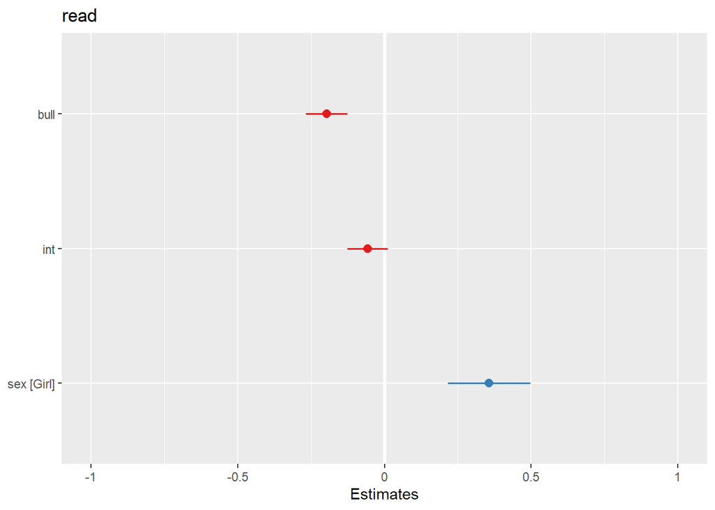

```r
plot_model(m2)
```

Обратите внимание, доверительные интервалы коэффициента переменной интерес пересекаются с 0 - с большой вероятностью коэффициент в генеральной совокупности равен 0, поэтому и незначимый.

P.S. Так как я добавила квадрат интереса в последний момент по результатам проведения лекции, совсем забыла написать задание проверить эту квадратичную связь. Но в целом вам нужно было для этого:  
1. Визуализировать свзяь мужду зависимой и независимой переменной

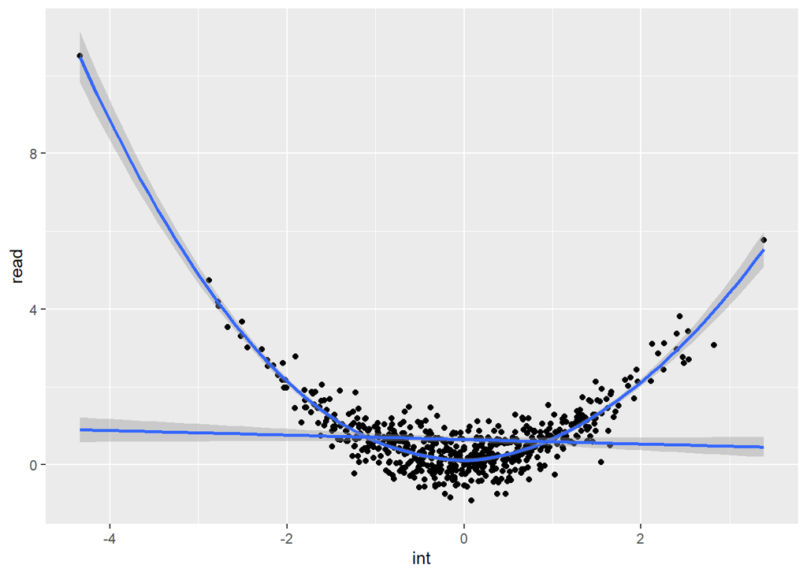

```r
ggplot(df2,aes(x = int, y = read)) +
  geom_point() +
  geom_smooth(method = "loess") +
  geom_smooth(method = "lm")
```

2. Понять, что связь квадратичная
3. Вставить в модель саму по себе независимую переменную и ее квадрат

```r
df2$int2 <- df2$int^2
m3 <-  lm(data = df2, read ~ bull + int  + int2  + sex)
summary(m3)
```

```
##
## Call:
## lm(formula = read ~ bull + int + int2 + sex, data = df2)
##
## Residuals:
##      Min       1Q   Median       3Q      Max
## -0.95237 -0.21332 -0.00814  0.20266  0.95108
##
## Coefficients:
##              Estimate Std. Error t value Pr(>|t|)
## (Intercept) -0.007077   0.019059  -0.371    0.711
## bull        -0.210242   0.012569 -16.727   <2e-16 ***
## int          0.005616   0.012369   0.454    0.650
## int2         0.505980   0.007788  64.971   <2e-16 ***
## sexGirl      0.284522   0.025234  11.275   <2e-16 ***
## ---
## Signif. codes:  0 '***' 0.001 '**' 0.01 '*' 0.05 '.' 0.1 ' ' 1
##
## Residual standard error: 0.3078 on 595 degrees of freedom
## Multiple R-squared:  0.8881, Adjusted R-squared:  0.8874
## F-statistic:  1181 on 4 and 595 DF,  p-value: < 2.2e-16
```

```r
tab_model(m2, m3)
```

|  | read |  |  | read |  |  |
| --- | --- | --- | --- | --- | --- | --- |
| Predictors | Estimates | CI | p | Estimates | CI | p |
| (Intercept) | 0.48 | 0.38 – 0.58 | **<0.001** | -0.01 | -0.04 – 0.03 | 0.711 |
| bull | -0.20 | -0.27 – -0.13 | **<0.001** | -0.21 | -0.23 – -0.19 | **<0.001** |
| int | -0.06 | -0.13 – 0.01 | 0.105 | 0.01 | -0.02 – 0.03 | 0.650 |
| sex [Girl] | 0.36 | 0.22 – 0.50 | **<0.001** | 0.28 | 0.23 – 0.33 | **<0.001** |
| int2 |  |  |  | 0.51 | 0.49 – 0.52 | **<0.001** |
| Observations | 600 |  |  | 600 |  |  |
| R<sup>2</sup> / R<sup>2</sup> adjusted | 0.094 / 0.090 |  |  | 0.888 / 0.887 |  |  |

Сравните обе модели - в последней линейной связи по-прежнему не видно, но вот для квадрата интереса коэффициент значимый и положительный - т.е. “усы” параболу направлены вверх.